# Growth of Entrepreneurial Activity in Lakes Region

DL

March 29, 2018

This is a modified version of a student project I assigned in my business statistics course during spring 2018. It aims to measure the entrepreneurial activity in the Lakes Region, using the U.S. Census data, American Community Survey. It covers two periods: 5-year estimates over 2007-2011 and 2012-2016.

```r
# Import data
data <- read.csv("C:/Users/sclee1/OneDrive/Documents/R/busStatistics/data/census2.csv")

str(data)
```

```
## 'data.frame':    64 obs. of  56 variables:
##  $ X                             : int  1 2 3 4 5 6 7 8 9 10 ...
##  $ Town                          : Factor w/ 32 levels "Alexandria","Alton",..: 1 2 3 4 5 6 7 8 9 10 ...
##  $ County                        : Factor w/ 6 levels " Belknap"," Carroll",..: 3 1 4 3 1 1 3 3 1 4 ...
##  $ popTotal                      : int  1836 5214 2422 1507 4564 7350 1179 3063 960 1120 ...
##  $ medianAge                     : num  39.2 44.6 47.3 39.6 38.4 41.1 47.7 47.1 49.2 40.5 ...
##  $ popNative_bornUSA             : int  1783 5023 2339 1445 4472 7141 1143 2961 920 1106 ...
##  $ popNative                     : int  1790 5040 2357 1445 4492 7170 1153 2992 924 1120 ...
##  $ popNaitve_bornNH              : int  1047 2160 1359 782 2247 4334 545 1538 453 548 ...
##  $ popMoved_otherState           : int  27 26 63 20 42 26 44 45 5 16 ...
##  $ popMoved_abroad               : int  0 34 39 29 0 0 0 8 0 0 ...
##  $ popCommute_car                : int  749 2312 1146 611 2304 3359 575 1337 453 556 ...
##  $ popCommute_publicT            : int  0 0 0 0 0 0 5 0 0 0 ...
##  $ popCommute_bicycle            : int  0 0 0 0 0 0 0 10 0 0 ...
##  $ popCommute_foot               : int  10 80 86 22 24 88 10 58 29 7 ...
```

[output cut: 42 more lines]

```r
summary(data)
```

```
##        X                 Town              County      popTotal
##  Min.   : 1.00   Alexandria: 2    Belknap     :22   Min.   :      541
##  1st Qu.:16.75   Alton     : 2    Carroll     :16   1st Qu.:     1496
##  Median :32.50   Andover   : 2    Grafton     :12   Median :     3013
##  Mean   :32.50   Ashland   : 2    Merrimack   :10   Mean   :  9812983
##  3rd Qu.:48.25   Barnstead : 2   New Hampshire: 2   3rd Qu.:     5516
##  Max.   :64.00   Belmont   : 2   United States: 2   Max.   :318558162
##                  (Other)   :52
##    medianAge     popNative_bornUSA     popNative
##  Min.   :37.00   Min.   :      481   Min.   :      487
##  1st Qu.:42.27   1st Qu.:     1433   1st Qu.:     1433
##  Median :46.30   Median :     2942   Median :     2966
##  Mean   :46.82   Mean   :  8398579   Mean   :  8537742
##  3rd Qu.:50.25   3rd Qu.:     5246   3rd Qu.:     5272
##  Max.   :59.50   Max.   :271639606   Max.   :276363808
##
##  popNaitve_bornNH    popMoved_otherState popMoved_abroad
##  Min.   :      145   Min.   :      5     Min.   :      0.0
##  1st Qu.:      664   1st Qu.:     27     1st Qu.:      0.0
##  Median :     1388   Median :     47     Median :      0.0
##  Mean   :  5746994   Mean   : 188730     Mean   :  50896.0
##  3rd Qu.:     2608   3rd Qu.:    103     3rd Qu.:     13.8
##  Max.   :186708691   Max.   :6111964     Max.   :1695894.0
##
##  popCommute_car      popCommute_publicT popCommute_bicycle
##  Min.   :      173   Min.   :      0    Min.   :     0.0
##  1st Qu.:      675   1st Qu.:      0    1st Qu.:     0.0
##  Median :     1418   Median :      0    Median :     0.0
##  Mean   :  3854261   Mean   : 225044    Mean   : 25412.4
##  3rd Qu.:     2323   3rd Qu.:      4    3rd Qu.:     0.2
##  Max.   :125037241   Max.   :7476312    Max.   :877995.0
##
##  popCommute_foot   popCommute_other    popCommute_home
##  Min.   :      0   Min.   :      0.0   Min.   :      6
##  1st Qu.:     10   1st Qu.:      4.8   1st Qu.:     39
##  Median :     24   Median :     13.5   Median :     70
##  Mean   : 125354   Mean   :  54174.8   Mean   : 197434
##  3rd Qu.:     74   3rd Qu.:     49.0   3rd Qu.:    145
##  Max.   :4030730   Max.   :1777051.0   Max.   :6661892
##
```

[output cut: 97 more lines]

```
##  Min.   :0.0000          Min.   :0.0000           Min.   : 0.3981
##  1st Qu.:0.4395          1st Qu.:0.2175           1st Qu.: 1.6705
##  Median :0.8309          Median :0.5455           Median : 2.3043
##  Mean   :1.2211          Mean   :0.7564           Mean   : 2.9100
##  3rd Qu.:1.5008          3rd Qu.:0.8935           3rd Qu.: 3.6064
##  Max.   :6.6234          Max.   :3.9224           Max.   :15.8965
##
##       Year          benchM
##  Min.   :2011   Min.   :1.0
##  1st Qu.:2011   1st Qu.:1.0
##  Median :2014   Median :1.5
##  Mean   :2014   Mean   :1.5
##  3rd Qu.:2016   3rd Qu.:2.0
##  Max.   :2016   Max.   :2.0
##                 NA's   :60
```

## Which towns has the highest entrepreurial spirit in the Lakes Region?

I used the self-employment income from the U.S. Census as a proxy for the entrepreneurial activity. And data visualization using the geofacet package helps reveal geographical patterns as it resemebles the actual geography of the Lakes Region. It’s apparent that Lake Winnipesaukee is the center of the entrepreneurial activity in the Lakes Region with Laconia at the top, followed by Wolfeboro, Gilford, Moultonboro and Meredith. But Laconia’s large number may just reflect a larger population and doesn’t necessarily mean that the city is more entrepreneurial than other towns.

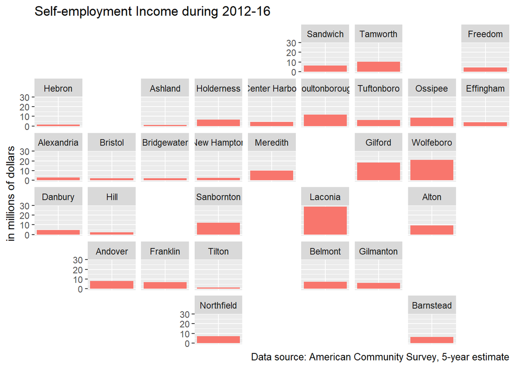

```r
# Load packages
library(dplyr)
library(ggplot2)
library(tidyr)
library(geofacet)
library(stringr)

# Create a grid, nh_grid for use of geofacet package
nameTown <- c("Sandwich", "Tamworth", "Freedom", "Hebron", "Ashland", "Holderness", "Center Harbor", "Moultonborough", "Tuftonboro", "Ossipee", "Effingham", "Alexandria", "Bristol", "Bridgewater", "New Hampton", "Meredith", "Laconia", "Gilford", "Wolfeboro", "Danbury", "Hill", "Sanbornton", "Belmont", "Alton", "Andover", "Franklin", "Tilton", "Gilmanton", "Northfield", "Barnstead")
code <- c("Sw", "Tw", "Fd", "Hb", "Al", "Hn", "Ch", "Mb", "Tb", "Op", "Eh", "Ad", "Bt", "Bw", "Nh", "Md", "Ln", "Gf", "Wb", "Db", "Hl", "Sb", "Bm", "At", "Av", "Fk", "Tt", "Gm", "Nf", "Bs")
row <- c(1,1,1,2,2,2,2,2,2,2,2,3,3,3,3,3,4,3,3,4,4,4,5,4,5,5,5,5,6,6)
col <- c(6,7,9,1,3,4,5,6,7,8,9,1,2,3,4,5,6,7,8,1,2,4,6,8,2,3,4,7,4,8)
nh_grid <- data.frame(nameTown, code, row, col)

data_geo <- data
colnames(data_geo)[colnames(data_geo) == "Town"] <- "nameTown"

data_geo %>%
  filter(Year ==2016,
         !nameTown %in% c("United States", "New Hampshire")) %>%
  select(nameTown, incomeLabor_SelfEmpl) %>%
  gather(var, value, c("incomeLabor_SelfEmpl")) %>%
  ggplot(aes(x = var, y = value/1000000, fill = var)) +
  geom_col(show.legend = FALSE) +
  facet_geo(~ nameTown, grid = nh_grid) +
  labs(title = "Self-employment Income during 2012-16",
       x = NULL,
       y = "in millions of dollars",
       caption = "Data source: American Community Survey, 5-year estimate") +
  theme(axis.text.x=element_blank(),
        axis.ticks.x=element_blank())
```

## Which town is entrepreneurial again?

So, in order to control for the size of population, let’s divide the self-employment income by population. Surprisingly, more than half of the towns make more income per person than the rest of the state from self-employment. Again, does this mean Lakes region towns are more entrepreneurial?

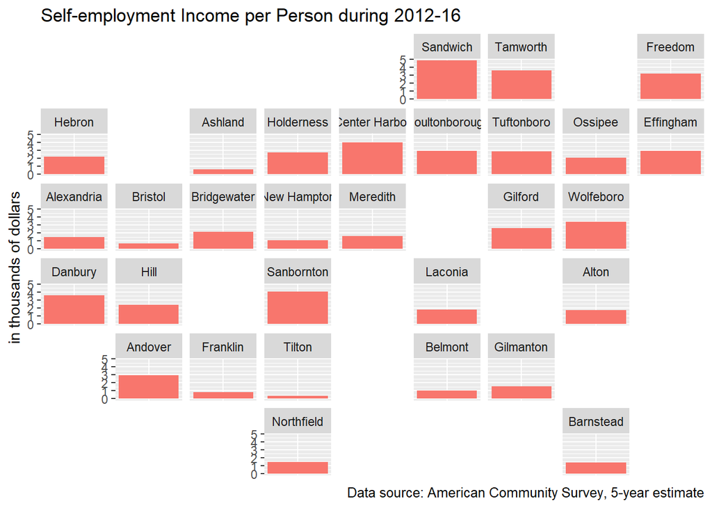

```r
data_geo %>%
  filter(Year ==2016,
         !nameTown %in% c("United States", "New Hampshire")) %>%
  mutate(incomeLabor_SelfEmpl_perPerson = incomeLabor_SelfEmpl / popTotal) %>%
  select(nameTown, incomeLabor_SelfEmpl_perPerson) %>%
  gather(var, value, c("incomeLabor_SelfEmpl_perPerson")) %>%
  ggplot(aes(x = var, y = value/1000, fill = var)) +
  geom_col(show.legend = FALSE) +
  facet_geo(~ nameTown, grid = nh_grid) +
  labs(title = "Self-employment Income per Person during 2012-16",
       x = NULL,
       y = "in thousands of dollars",
       caption = "Data source: American Community Survey, 5-year estimate") +
  theme(axis.text.x=element_blank(),
        axis.ticks.x=element_blank())
```

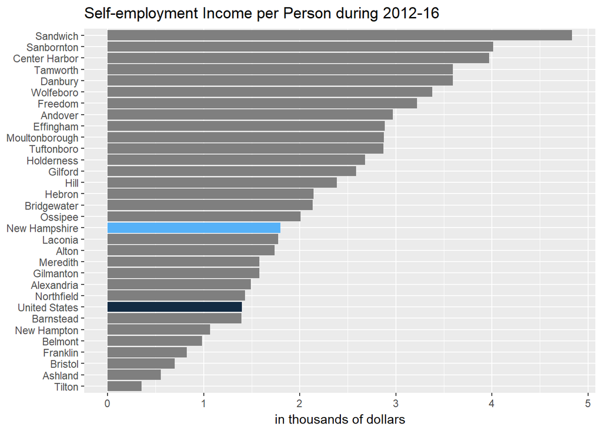

```r
# self-employment income per person
data %>%
  filter(Year ==2016) %>%
  mutate(incomeLabor_SelfEmpl_perPerson = incomeLabor_SelfEmpl / popTotal) %>%
  select(Town, incomeLabor_SelfEmpl_perPerson, benchM) %>%
  ggplot(aes(reorder(x = Town, incomeLabor_SelfEmpl_perPerson), y = incomeLabor_SelfEmpl_perPerson/1000, fill = benchM)) +
  geom_col(show.legend = FALSE) +
  coord_flip() +
  labs(title = "Self-employment Income per Person during 2012-16",
       x = NULL,
       y = "in thousands of dollars")
```

## Looking at wage and salary income

More self-employment income may mean a higher level of entrepreneurial activity. But it may also reflect lack of wage and salary jobs. So I look at wage and salary income per person.When measured by wage and salary income, only Gilford did better than the rest of the state. And less than half of the towns did better than the rest of the country. It speaks volumes about lack of jobs, in particular high-paying jobs. A greater portion of the resident population earn their income from working for themselves than the rest of the state, probably becasue they are forced to do so for lack of alternatives.

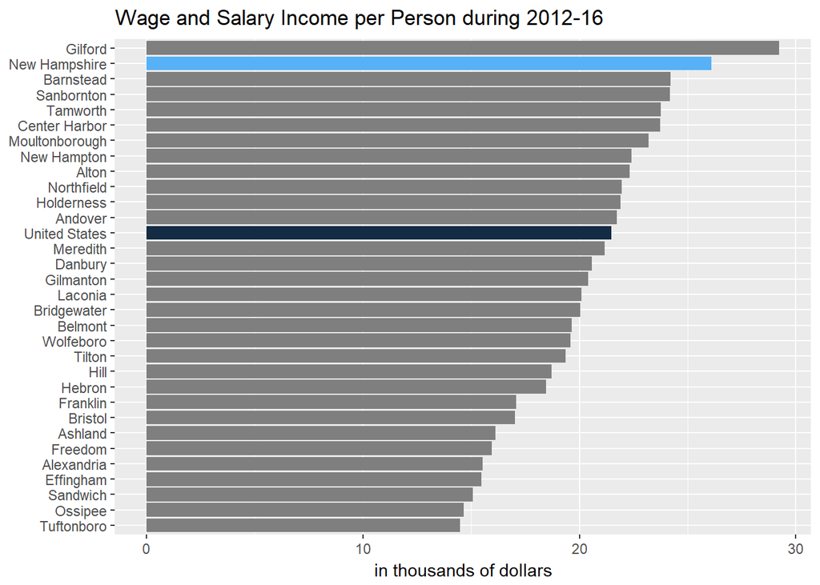

```r
# Wage and salary income per person
data %>%
  filter(Year ==2016) %>%
  mutate(incomeLabor_WageSalary_perPerson = incomeLabor_WageSalary / popTotal) %>%
  select(Town, incomeLabor_WageSalary_perPerson, benchM) %>%
  ggplot(aes(reorder(x = Town, incomeLabor_WageSalary_perPerson), y = incomeLabor_WageSalary_perPerson/1000, fill = benchM)) +
  geom_col(show.legend = FALSE) +
  coord_flip() +
  labs(title = "Wage and Salary Income per Person during 2012-16",
       x = NULL,
       y = "in thousands of dollars")
```

When looking at labor income, which is the sum of self-employment income and wage and salary income, the story remains the same. Only Gilford and Sanbornton earn more income from current labor in comparison to the rest of the state.

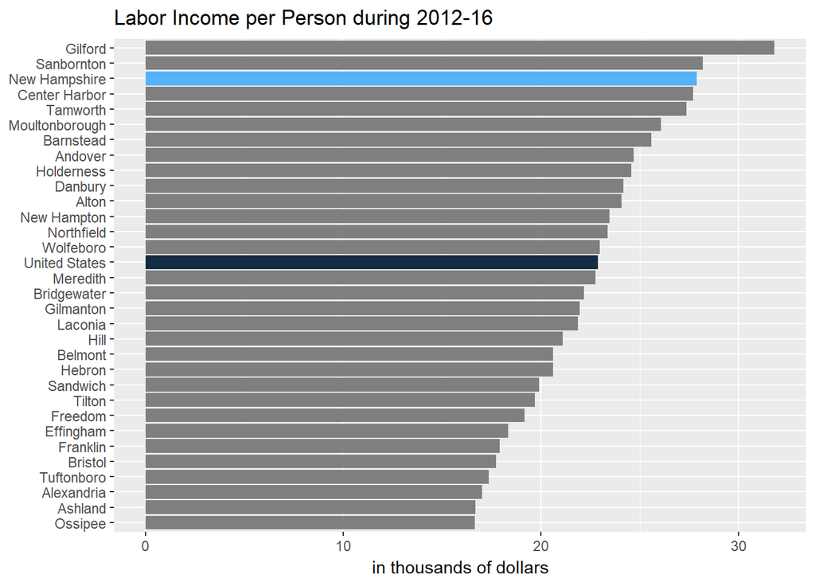

```r
# Labor income per person
data %>%
  filter(Year ==2016) %>%
  mutate(incomeLabor_perPerson = incomeLabor / popTotal) %>%
  select(Town, incomeLabor_perPerson, benchM) %>%
  ggplot(aes(reorder(x = Town, incomeLabor_perPerson), y = incomeLabor_perPerson/1000, fill = benchM)) +
  geom_col(show.legend = FALSE) +
  coord_flip() +
  labs(title = "Labor Income per Person during 2012-16",
       x = NULL,
       y = "in thousands of dollars")
```

In addition to labor income, there is an alternative soruce of income, non-labor income, which comprises 1) investment income (interest, dividends, and rental income) and 2) transfer payment income (social security, medicare, welfare, etc). When considering non-labor income, many towns do better than the rest of the state reflecting a larger porportion of retirees in the Lakes Region.

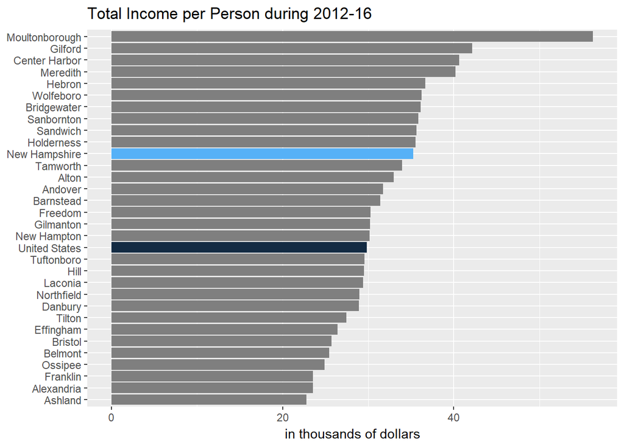

```r
# Total income per person
data %>%
  filter(Year ==2016) %>%
  mutate(incomeTotal_perPerson = incomeTotal / popTotal) %>%
  select(Town, incomeTotal_perPerson, benchM) %>%
  ggplot(aes(reorder(x = Town, incomeTotal_perPerson), y = incomeTotal_perPerson/1000, fill = benchM)) +
  geom_col(show.legend = FALSE) +
  coord_flip() +
  labs(title = "Total Income per Person during 2012-16",
       x = NULL,
       y = "in thousands of dollars")
```

investment income versus transfer payment

I divided investment income by transfer payment income to get the ratio, which reveals which towns rely more on transfer payment income and which towns has rich retirees.

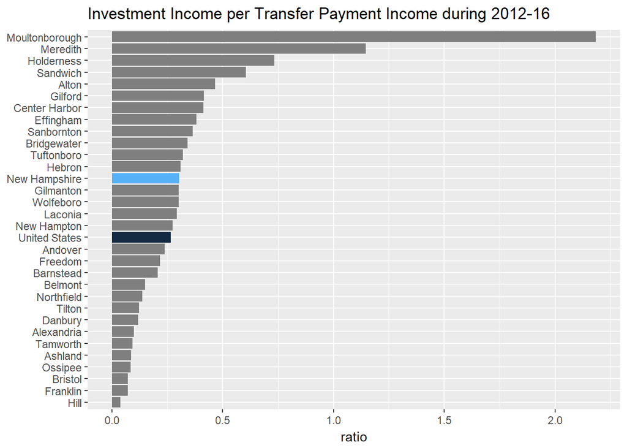

```r
# Total income per person
data %>%
  filter(Year ==2016) %>%
  mutate(ratio = incomeInvest / incomeTransferPayment) %>%
  select(Town, ratio, benchM) %>%
  ggplot(aes(reorder(x = Town, ratio), y = ratio, fill = benchM)) +
  geom_col(show.legend = FALSE) +
  coord_flip() +
  labs(title = "Investment Income per Transfer Payment Income during 2012-16",
       x = NULL,
       y = "ratio")
```

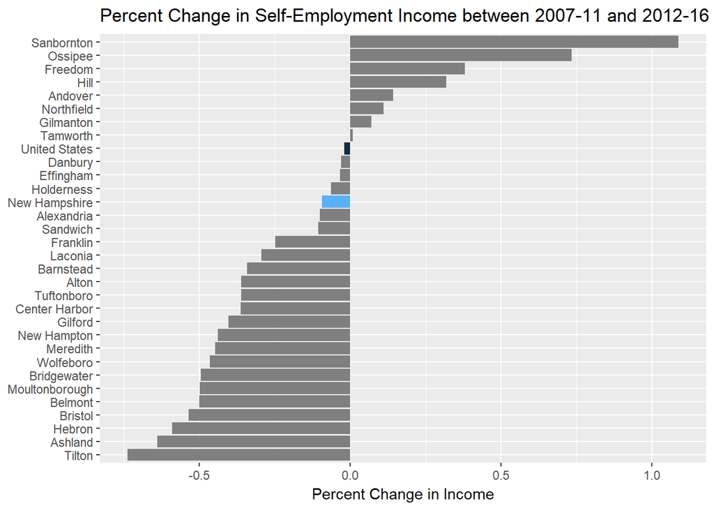

```r
data %>%
  select(Town, incomeLabor_SelfEmpl, Year, benchM) %>%
  mutate(Year = paste0("Yr",Year)) %>%
  spread(Year, incomeLabor_SelfEmpl) %>%
  ggplot(aes(reorder(x = Town, (Yr2016-Yr2011)/Yr2011), y = (Yr2016-Yr2011)/Yr2011, fill = benchM)) +
  geom_col(show.legend = FALSE) +
  coord_flip() +
  labs(title = "Percent Change in Self-Employment Income between 2007-11 and 2012-16",
       x = NULL,
       y = "Percent Change in Income")
```

## Percent change by geofacet

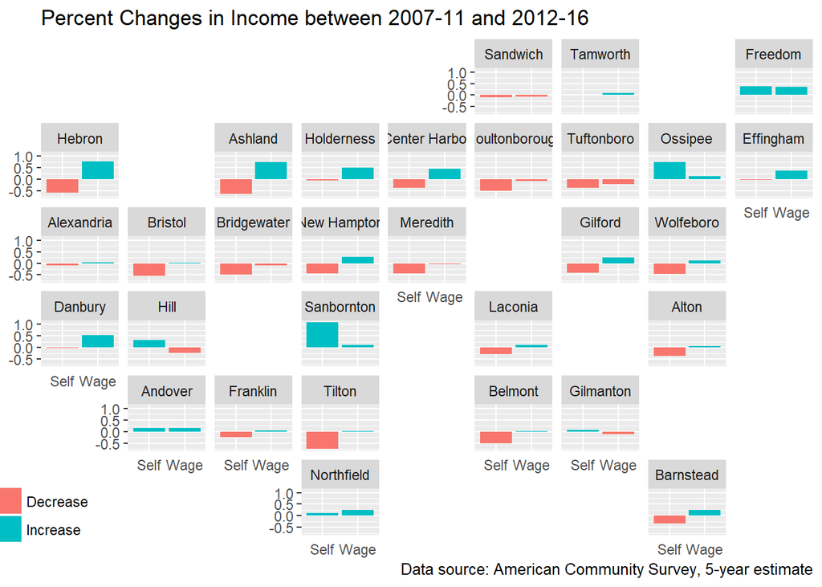

```r
library(stringr)
library(geofacet)
# Create a grid, nh_grid for use of geofacet package
nameTown <- c("Sandwich", "Tamworth", "Freedom", "Hebron", "Ashland", "Holderness", "Center Harbor", "Moultonborough", "Tuftonboro", "Ossipee", "Effingham", "Alexandria", "Bristol", "Bridgewater", "New Hampton", "Meredith", "Laconia", "Gilford", "Wolfeboro", "Danbury", "Hill", "Sanbornton", "Belmont", "Alton", "Andover", "Franklin", "Tilton", "Gilmanton", "Northfield", "Barnstead")
code <- c("Sw", "Tw", "Fd", "Hb", "Al", "Hn", "Ch", "Mb", "Tb", "Op", "Eh", "Ad", "Bt", "Bw", "Nh", "Md", "Ln", "Gf", "Wb", "Db", "Hl", "Sb", "Bm", "At", "Av", "Fk", "Tt", "Gm", "Nf", "Bs")
row <- c(1,1,1,2,2,2,2,2,2,2,2,3,3,3,3,3,4,3,3,4,4,4,5,4,5,5,5,5,6,6)
col <- c(6,7,9,1,3,4,5,6,7,8,9,1,2,3,4,5,6,7,8,1,2,4,6,8,2,3,4,7,4,8)
nh_grid <- data.frame(nameTown, code, row, col)

data_geo <- data
colnames(data_geo)[colnames(data_geo) == "Town"] <- "nameTown"

data_geo %>%
  filter(!nameTown %in% c("United States", "New Hampshire")) %>%
  select(nameTown, incomeLabor_SelfEmpl, incomeLabor_WageSalary, Year) %>%
  mutate(Year = paste0("Yr",Year)) %>%
  gather(var, value, c("incomeLabor_SelfEmpl", "incomeLabor_WageSalary")) %>%
  mutate(var = str_extract(var, "Self|Wage")) %>% #change the text for shorter axis text in graph
  spread(Year, value)  %>%
  ggplot(aes(x = var, y = (Yr2016-Yr2011)/Yr2011, fill = Yr2016-Yr2011 > 0)) +
  geom_col() +
  facet_geo(~ nameTown, grid = nh_grid) +
  labs(title = "Percent Changes in Income between 2007-11 and 2012-16",
       x = NULL,
       y = NULL,
       caption = "Data source: American Community Survey, 5-year estimate") +
  theme(axis.ticks.x=element_blank(),
        legend.position= c(0,0.05),
        legend.title=element_blank()) +
  scale_fill_discrete(labels=c("Decrease", "Increase"))
```